# Assignment 3 - Linear models for Cirrhosis dataset

Sergi Mayol y Toni Garri

2023-12-07

# Introduction

During 1974 to 1984, 424 PBC patients referred to the Mayo Clinic qualified for the randomized placebocontrolled trial testing the drug D-penicillamine. Of these, the initial 312 patients took part in the trial and have mostly comprehensive data. The remaining 112 patients didn’t join the clinical trial but agreed to record basic metrics and undergo survival tracking. Six of these patients were soon untraceable after their diagnosis, leaving data for 106 of these individuals in addition to the 312 who were part of the randomized trial.

# Study Problem Statement

The objective of this assignment is to predict the survival state of patients with liver cirrhosis.

# Libraries

For this assignment, the following libraries are used:

```r
library(GGally)
```

```r
library(ggplot2)
library(dplyr)
library(gridExtra)
library(ggcorrplot)
library(mlpack) # Used to create the different models used in this assignment
library(caret) # Used to obtain all the metrics of the different models
```

# Data

This assignment uses the data frame Cirrhosis dataset that can be found in the DATASET folder.

```r
dataset <- read.csv("../datasets/cirrhosis.csv")
```

## Data preparation

Let’s study the dataset to see which data will be useful to our study. First of all let’s transform to factor all the character data to see in the summary all the NA’s.

```r
temp_dataset <- dataset
temp_dataset[, c("Status", "Drug", "Sex", "Ascites", "Hepatomegaly", "Spiders", "Edema")] <- lapply(temp_dataset[, c("Status", "Drug", "Sex", "Ascites", "Hepatomegaly", "Spiders", "Edema")], as.factor)
summary(temp_dataset)
```

```
##        ID            N_Days     Status                Drug          Age
##  Min.   :  1.0   Min.   :  41   C :232   D-penicillamine:158   Min.   : 9598
##  1st Qu.:105.2   1st Qu.:1093   CL: 25   Placebo        :154   1st Qu.:15644
##  Median :209.5   Median :1730   D :161   NA's           :106   Median :18628
##  Mean   :209.5   Mean   :1918                                  Mean   :18533
##  3rd Qu.:313.8   3rd Qu.:2614                                  3rd Qu.:21272
##  Max.   :418.0   Max.   :4795                                  Max.   :28650
##
##  Sex     Ascites    Hepatomegaly Spiders    Edema     Bilirubin
##  F:374   N   :288   N   :152     N   :222   N:354   Min.   : 0.300
##  M: 44   Y   : 24   Y   :160     Y   : 90   S: 44   1st Qu.: 0.800
##          NA's:106   NA's:106     NA's:106   Y: 20   Median : 1.400
##                                                     Mean   : 3.221
##                                                     3rd Qu.: 3.400
##                                                     Max.   :28.000
##
##   Cholesterol        Albumin          Copper          Alk_Phos
##  Min.   : 120.0   Min.   :1.960   Min.   :  4.00   Min.   :  289.0
##  1st Qu.: 249.5   1st Qu.:3.243   1st Qu.: 41.25   1st Qu.:  871.5
##  Median : 309.5   Median :3.530   Median : 73.00   Median : 1259.0
##  Mean   : 369.5   Mean   :3.497   Mean   : 97.65   Mean   : 1982.7
##  3rd Qu.: 400.0   3rd Qu.:3.770   3rd Qu.:123.00   3rd Qu.: 1980.0
##  Max.   :1775.0   Max.   :4.640   Max.   :588.00   Max.   :13862.4
##  NA's   :134                      NA's   :108      NA's   :106
##       SGOT        Tryglicerides      Platelets      Prothrombin
##  Min.   : 26.35   Min.   : 33.00   Min.   : 62.0   Min.   : 9.00
##  1st Qu.: 80.60   1st Qu.: 84.25   1st Qu.:188.5   1st Qu.:10.00
##  Median :114.70   Median :108.00   Median :251.0   Median :10.60
##  Mean   :122.56   Mean   :124.70   Mean   :257.0   Mean   :10.73
##  3rd Qu.:151.90   3rd Qu.:151.00   3rd Qu.:318.0   3rd Qu.:11.10
##  Max.   :457.25   Max.   :598.00   Max.   :721.0   Max.   :18.00
##  NA's   :106      NA's   :136      NA's   :11      NA's   :2
##      Stage
##  Min.   :1.000
##  1st Qu.:2.000
##  Median :3.000
##  Mean   :3.024
##  3rd Qu.:4.000
##  Max.   :4.000
##  NA's   :6
```

As we can see there are a lot of missing values, and that is a problem that we have to solve in some way.

Another important thing to do previous to deal with the NA’s is seeing the type of the data:

```r
str(dataset)
```

```
## 'data.frame':    418 obs. of  20 variables:
##  $ ID           : int  1 2 3 4 5 6 7 8 9 10 ...
##  $ N_Days       : int  400 4500 1012 1925 1504 2503 1832 2466 2400 51 ...
##  $ Status       : chr  "D" "C" "D" "D" ...
##  $ Drug         : chr  "D-penicillamine" "D-penicillamine" "D-penicillamine" "D-penicillamine" ...
##  $ Age          : int  21464 20617 25594 19994 13918 24201 20284 19379 15526 25772 ...
##  $ Sex          : chr  "F" "F" "M" "F" ...
##  $ Ascites      : chr  "Y" "N" "N" "N" ...
##  $ Hepatomegaly : chr  "Y" "Y" "N" "Y" ...
##  $ Spiders      : chr  "Y" "Y" "N" "Y" ...
##  $ Edema        : chr  "Y" "N" "S" "S" ...
##  $ Bilirubin    : num  14.5 1.1 1.4 1.8 3.4 0.8 1 0.3 3.2 12.6 ...
##  $ Cholesterol  : int  261 302 176 244 279 248 322 280 562 200 ...
##  $ Albumin      : num  2.6 4.14 3.48 2.54 3.53 3.98 4.09 4 3.08 2.74 ...
##  $ Copper       : int  156 54 210 64 143 50 52 52 79 140 ...
##  $ Alk_Phos     : num  1718 7395 516 6122 671 ...
##  $ SGOT         : num  137.9 113.5 96.1 60.6 113.2 ...
##  $ Tryglicerides: int  172 88 55 92 72 63 213 189 88 143 ...
##  $ Platelets    : int  190 221 151 183 136 NA 204 373 251 302 ...
##  $ Prothrombin  : num  12.2 10.6 12 10.3 10.9 11 9.7 11 11 11.5 ...
##  $ Stage        : int  4 3 4 4 3 3 3 3 2 4 ...
```

Let’s simplify the name of the dataset to `df` and also to keep the original without modifications.

```r
df <- dataset
```

We can remove the ID from the dataset because it’s a value that is used only to index the data and has no other important relation with the rest.

```r
df <- subset(df, select = -ID)
```

As it is said in the introduction, there are some patients that didn’t took neither the drug or the placebo statement, and those values figure as NA’s so let’s get rid of them changing them to `None`.

```r
df <- df %>% mutate(Drug = ifelse(is.na(Drug), "None", Drug))
```

Once we got rid of the NA’s in `Drug` we can plot it to see that like it was said in the introduction, there are 106 people that didn’t took anything.

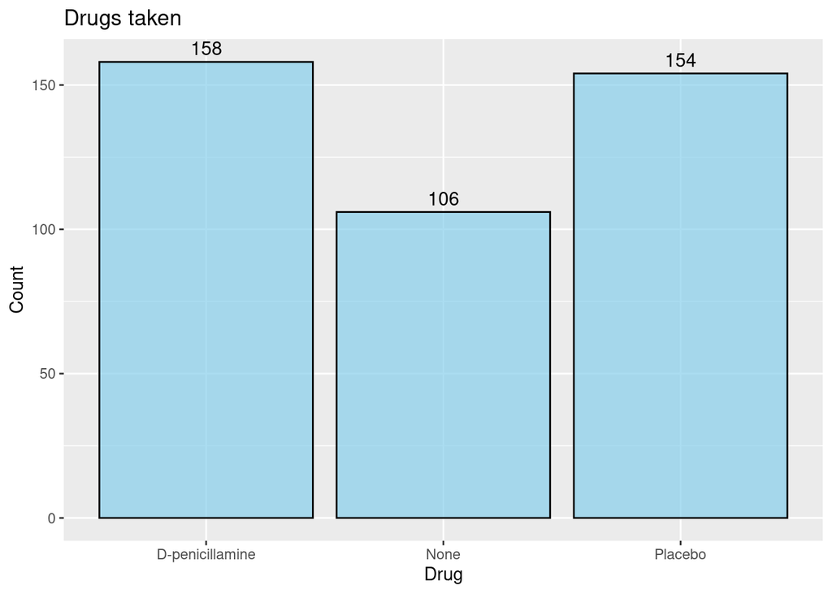

```r
ggplot(df, aes(x = Drug)) +
  geom_bar(fill = "skyblue", color = "black", alpha = 0.7) +
  geom_text(stat = "count", aes(label = after_stat(count)), vjust = -0.5, color = "black", size = 4) +
  labs(title = "Drugs taken", x = "Drug", y = "Count")
```

So now let’s clean all the data getting rid of the NA’s. In this case when it’s a chr data we change the NA for `None`, when is a numeric we use the mean of that variable except for Stage that we use the median because it does not make sense to have half a stage.

```r
df <- df %>% mutate(Ascites = ifelse(is.na(Ascites), "None", Ascites))
df <- df %>% mutate(Hepatomegaly = ifelse(is.na(Hepatomegaly), "None", Hepatomegaly))
df <- df %>% mutate(Spiders = ifelse(is.na(Spiders), "None", Spiders))
df <- df %>% mutate(Cholesterol = ifelse(is.na(Cholesterol), mean(Cholesterol, na.rm = TRUE), Cholesterol))
df <- df %>% mutate(Alk_Phos = ifelse(is.na(Alk_Phos), mean(Alk_Phos, na.rm = TRUE), Alk_Phos))
df <- df %>% mutate(SGOT = ifelse(is.na(SGOT), mean(SGOT, na.rm = TRUE), SGOT))
df <- df %>% mutate(Copper = ifelse(is.na(Copper), mean(Copper, na.rm = TRUE), Copper))
df <- df %>% mutate(Tryglicerides = ifelse(is.na(Tryglicerides), mean(Tryglicerides, na.rm = TRUE), Tryglicerides))
df <- df %>% mutate(Platelets = ifelse(is.na(Platelets), mean(Platelets, na.rm = TRUE), Platelets))
df <- df %>% mutate(Prothrombin = ifelse(is.na(Prothrombin), mean(Prothrombin, na.rm = TRUE), Prothrombin))
df <- df %>% mutate(Stage = ifelse(is.na(Stage), median(Stage, na.rm = TRUE), Stage))
summary(df)
```

```
##      N_Days        Status              Drug                Age
##  Min.   :  41   Length:418         Length:418         Min.   : 9598
##  1st Qu.:1093   Class :character   Class :character   1st Qu.:15644
##  Median :1730   Mode  :character   Mode  :character   Median :18628
##  Mean   :1918                                         Mean   :18533
##  3rd Qu.:2614                                         3rd Qu.:21272
##  Max.   :4795                                         Max.   :28650
##      Sex              Ascites          Hepatomegaly         Spiders
##  Length:418         Length:418         Length:418         Length:418
##  Class :character   Class :character   Class :character   Class :character
##  Mode  :character   Mode  :character   Mode  :character   Mode  :character
##
##
##
##     Edema             Bilirubin       Cholesterol        Albumin
##  Length:418         Min.   : 0.300   Min.   : 120.0   Min.   :1.960
##  Class :character   1st Qu.: 0.800   1st Qu.: 273.0   1st Qu.:3.243
##  Mode  :character   Median : 1.400   Median : 369.5   Median :3.530
##                     Mean   : 3.221   Mean   : 369.5   Mean   :3.497
##                     3rd Qu.: 3.400   3rd Qu.: 369.5   3rd Qu.:3.770
##                     Max.   :28.000   Max.   :1775.0   Max.   :4.640
##      Copper          Alk_Phos          SGOT        Tryglicerides
##  Min.   :  4.00   Min.   :  289   Min.   : 26.35   Min.   : 33.0
##  1st Qu.: 51.25   1st Qu.: 1016   1st Qu.: 91.00   1st Qu.: 95.0
##  Median : 97.65   Median : 1717   Median :122.56   Median :124.7
##  Mean   : 97.65   Mean   : 1983   Mean   :122.56   Mean   :124.7
##  3rd Qu.:100.75   3rd Qu.: 1983   3rd Qu.:135.75   3rd Qu.:127.8
##  Max.   :588.00   Max.   :13862   Max.   :457.25   Max.   :598.0
##    Platelets      Prothrombin        Stage
##  Min.   : 62.0   Min.   : 9.00   Min.   :1.000
##  1st Qu.:190.0   1st Qu.:10.00   1st Qu.:2.000
##  Median :253.0   Median :10.60   Median :3.000
##  Mean   :257.0   Mean   :10.73   Mean   :3.024
##  3rd Qu.:315.5   3rd Qu.:11.10   3rd Qu.:4.000
##  Max.   :721.0   Max.   :18.00   Max.   :4.000
```

Now that all the data is cleaned we can start to look to other things, for example the `Status` of the patients, and it is main feature that we would use in this study to help us answering to the question raised above.

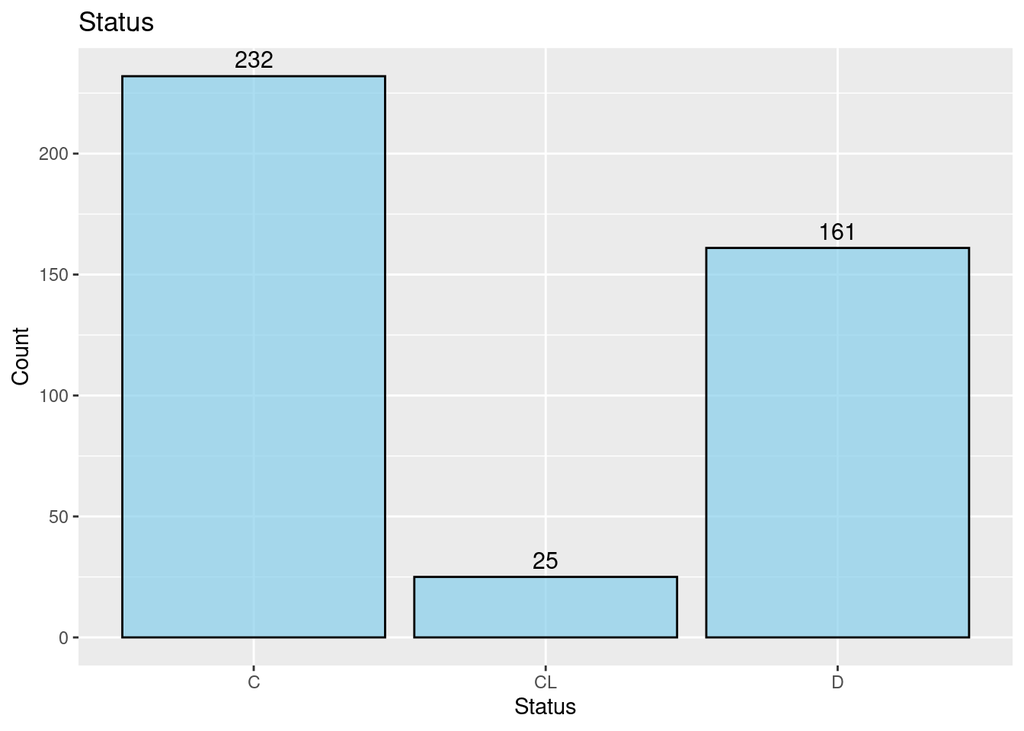

```r
ggplot(df, aes(x = Status)) +
  geom_bar(fill = "skyblue", color = "black", alpha = 0.7) +
  geom_text(stat = "count", aes(label = after_stat(count)), vjust = -0.5, color = "black", size = 4) +
  labs(title = "Status", x = "Status", y = "Count")
```

```r
df$AgeInYear <- df$Age / 365.25 # 366
df$AgeInYear
```

```
##   [1] 58.76523 56.44627 70.07255 54.74059 38.10541 66.25873 55.53457 53.05681
##   [9] 42.50787 70.55989 53.71389 59.13758 45.68925 56.22177 64.64613 40.44353
##  [17] 52.18344 53.93018 49.56057 59.95346 64.18891 56.27652 55.96715 44.52019
##  [25] 45.07324 52.02464 54.43943 44.94730 63.87680 41.38535 41.55236 53.99589
##  [33] 51.28268 52.06023 48.61875 56.41068 61.72758 36.62697 55.39220 46.66940
##  [41] 33.63450 33.69473 48.87064 37.58248 41.79329 45.79877 47.42779 49.13621
##  [49] 61.15264 53.50856 52.08761 50.54073 67.40862 39.19781 65.76318 33.61807
##  [57] 53.57153 44.56947 40.39425 58.38193 43.89870 60.70637 46.62834 62.90760
##  [65] 40.20260 46.45311 51.28816 32.61328 49.33881 56.39973 48.84600 32.49281
##  [73] 38.49418 51.92060 43.51814 51.94251 49.82615 47.94524 46.51608 67.41136
##  [81] 63.26352 67.31006 56.01369 55.83025 47.21697 52.75838 37.27858 41.39357
##  [89] 52.44353 33.47570 45.60712 76.70910 36.53388 53.91650 46.39014 48.84600
##  [97] 71.89322 28.88433 48.46817 51.46886 44.95003 56.56947 48.96372 43.01711
## [105] 34.03970 68.50924 62.52156 50.35729 44.06297 38.91034 41.15264 55.45791
## [113] 51.23340 52.82683 42.63929 61.07050 49.65640 48.85421 54.25599 35.15127
```

[output cut: 38 more lines]

```r
df$year_group <- cut(df$AgeInYear,
  breaks = seq(0, 100, by = 10),
  include.lowest = TRUE,
  labels = FALSE
)
df$year_group
```

```
##   [1] 6 6 8 6 4 7 6 6 5 8 6 6 5 6 7 5 6 6 5 6 7 6 6 5 5 6 6 5 7 5 5 6 6 6 5 6 7
##  [38] 4 6 5 4 4 5 4 5 5 5 5 7 6 6 6 7 4 7 4 6 5 5 6 5 7 5 7 5 5 6 4 5 6 5 4 4 6
##  [75] 5 6 5 5 5 7 7 7 6 6 5 6 4 5 6 4 5 8 4 6 5 5 8 3 5 6 5 6 5 5 4 7 7 6 5 4 5
## [112] 6 6 6 5 7 5 5 6 4 7 6 5 6 5 6 5 5 7 5 7 5 7 5 5 6 7 6 5 6 5 6 5 6 6 4 8 4
## [149] 7 4 6 7 5 7 5 6 5 4 5 6 5 6 6 5 6 5 7 5 4 5 6 5 4 6 6 5 6 8 5 5 5 6 5 4 5
## [186] 8 4 7 6 6 6 6 6 5 3 6 5 4 5 4 5 7 4 7 5 7 8 7 6 5 6 5 6 7 5 6 4 4 5 7 6 5
## [223] 7 4 4 6 6 4 7 4 6 6 5 4 4 4 6 7 5 6 5 7 7 5 5 4 5 6 5 5 6 7 8 4 4 4 6 6 6
## [260] 8 6 5 4 5 5 6 8 6 5 3 6 4 5 5 4 6 4 4 6 5 7 4 7 5 5 4 6 5 7 7 5 6 6 7 4 4
## [297] 6 6 4 6 5 4 7 4 5 6 4 7 6 7 4 4 6 7 6 8 7 5 5 5 7 7 4 7 4 6 5 6 7 6 5 6 6
## [334] 6 6 7 6 5 6 6 6 6 5 4 5 8 6 6 6 5 7 6 7 6 4 7 6 7 5 7 5 5 5 6 7 7 7 5 5 6
## [371] 6 4 7 6 6 5 4 6 7 4 5 6 4 6 6 6 5 4 7 7 5 7 6 6 4 6 7 7 5 5 7 6 7 4 6 5 6
## [408] 6 5 4 6 7 4 7 4 6 6 6
```

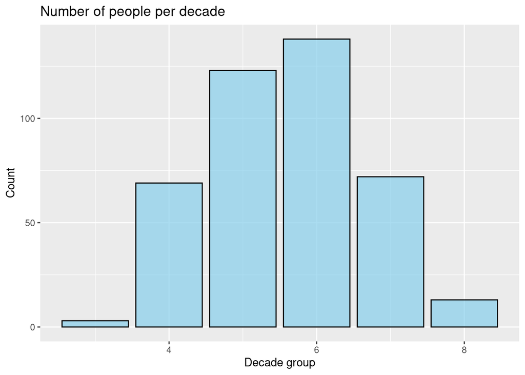

```r
ggplot(df, aes(x = year_group)) +
  geom_bar(fill = "skyblue", color = "black", alpha = 0.7) +
  labs(title = "Number of people per decade", x = "Decade group", y = "Count")
```

To see which features will be a good contender to be picked to make the prediction let’s make a correlation matrix to see which are more promising.

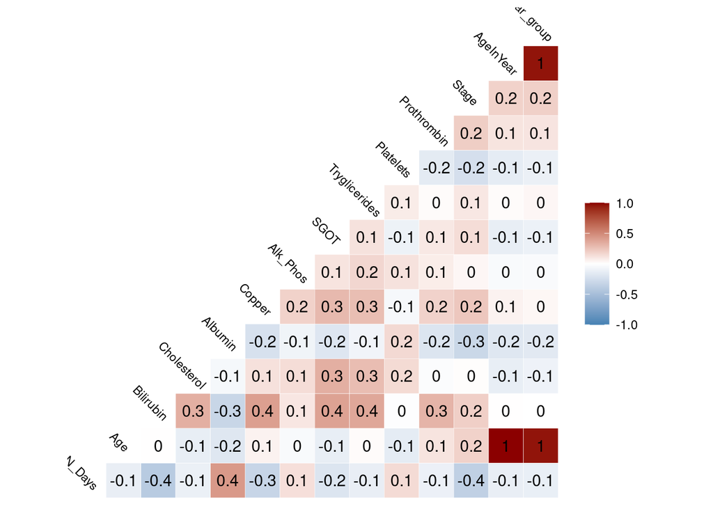

```r
plot_corr <- ggcorr(
  data = df,
  low = "steelblue",
  mid = "white",
  high = "darkred",
  label = TRUE,
  label_alpha = 0,
  angle = -45,
  max_size = 10,
  min_size = 2,
  size = 3,
  hjust = 0.75
)
plot_corr +
  theme(text = element_text(size = 8))
```

As we can see, a combination of all or some of the variables related to medical condition are a good way to try to predict the state of the patient.

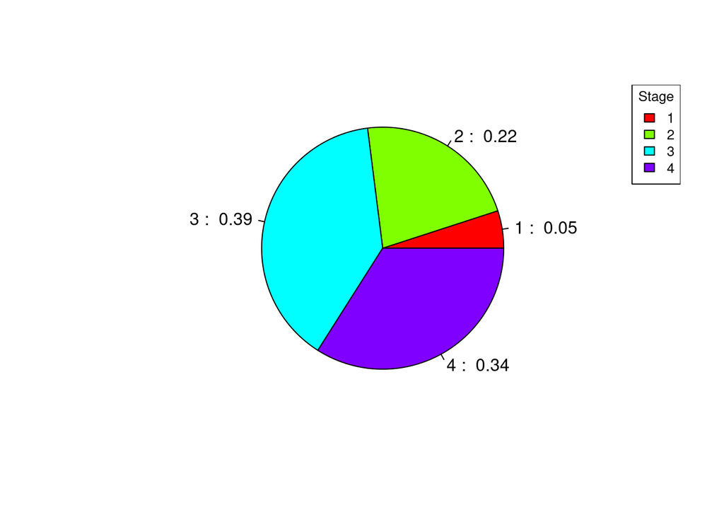

```r
stage_proportions <- round(prop.table(table(df$Stage)), 2)
pie(stage_proportions, labels = paste(names(stage_proportions), ": ", stage_proportions), col = rainbow(length(stage_proportions)))
legend("topright", legend = names(stage_proportions), fill = rainbow(length(stage_proportions)), cex = 0.8, title = "Stage")
```

This plot shows us that the majority of the patients are in the third stage followed for the fourth stage.

## Data selection

Seeing all the previous information we have decided to split the data and only pick the variables related to the health state of the patient and his stage.

```r
stage_df <- subset(df, select = c(Stage, Ascites, Hepatomegaly, Spiders, Cholesterol, Alk_Phos, Bilirubin, Albumin, Copper, SGOT, Tryglicerides, Platelets, Prothrombin))
```

Now we can see the data that will be used to make the predictions.

```r
summary(stage_df)
```

```
##      Stage         Ascites          Hepatomegaly         Spiders
##  Min.   :1.000   Length:418         Length:418         Length:418
##  1st Qu.:2.000   Class :character   Class :character   Class :character
##  Median :3.000   Mode  :character   Mode  :character   Mode  :character
##  Mean   :3.024
##  3rd Qu.:4.000
##  Max.   :4.000
##   Cholesterol        Alk_Phos       Bilirubin         Albumin
##  Min.   : 120.0   Min.   :  289   Min.   : 0.300   Min.   :1.960
##  1st Qu.: 273.0   1st Qu.: 1016   1st Qu.: 0.800   1st Qu.:3.243
##  Median : 369.5   Median : 1717   Median : 1.400   Median :3.530
##  Mean   : 369.5   Mean   : 1983   Mean   : 3.221   Mean   :3.497
##  3rd Qu.: 369.5   3rd Qu.: 1983   3rd Qu.: 3.400   3rd Qu.:3.770
##  Max.   :1775.0   Max.   :13862   Max.   :28.000   Max.   :4.640
##      Copper            SGOT        Tryglicerides     Platelets
##  Min.   :  4.00   Min.   : 26.35   Min.   : 33.0   Min.   : 62.0
##  1st Qu.: 51.25   1st Qu.: 91.00   1st Qu.: 95.0   1st Qu.:190.0
##  Median : 97.65   Median :122.56   Median :124.7   Median :253.0
##  Mean   : 97.65   Mean   :122.56   Mean   :124.7   Mean   :257.0
##  3rd Qu.:100.75   3rd Qu.:135.75   3rd Qu.:127.8   3rd Qu.:315.5
##  Max.   :588.00   Max.   :457.25   Max.   :598.0   Max.   :721.0
##   Prothrombin
##  Min.   : 9.00
##  1st Qu.:10.00
##  Median :10.60
##  Mean   :10.73
##  3rd Qu.:11.10
##  Max.   :18.00
```

```r
str(stage_df)
```

```
## 'data.frame':    418 obs. of  13 variables:
##  $ Stage        : num  4 3 4 4 3 3 3 3 2 4 ...
##  $ Ascites      : chr  "Y" "N" "N" "N" ...
##  $ Hepatomegaly : chr  "Y" "Y" "N" "Y" ...
##  $ Spiders      : chr  "Y" "Y" "N" "Y" ...
##  $ Cholesterol  : num  261 302 176 244 279 248 322 280 562 200 ...
##  $ Alk_Phos     : num  1718 7395 516 6122 671 ...
##  $ Bilirubin    : num  14.5 1.1 1.4 1.8 3.4 0.8 1 0.3 3.2 12.6 ...
##  $ Albumin      : num  2.6 4.14 3.48 2.54 3.53 3.98 4.09 4 3.08 2.74 ...
##  $ Copper       : num  156 54 210 64 143 50 52 52 79 140 ...
##  $ SGOT         : num  137.9 113.5 96.1 60.6 113.2 ...
##  $ Tryglicerides: num  172 88 55 92 72 63 213 189 88 143 ...
##  $ Platelets    : num  190 221 151 183 136 ...
##  $ Prothrombin  : num  12.2 10.6 12 10.3 10.9 11 9.7 11 11 11.5 ...
```

With another correlation plot we can see better the relation between the variables selected.

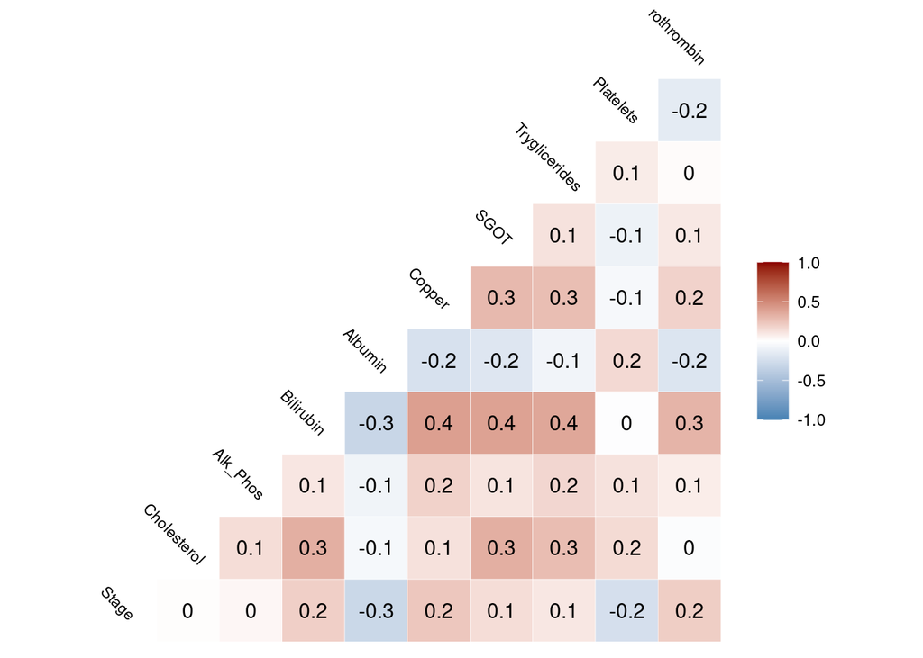

```r
plot_corr <- ggcorr(
  data = stage_df,
  low = "steelblue",
  mid = "white",
  high = "darkred",
  label = TRUE,
  label_alpha = 0,
  angle = -45,
  max_size = 10,
  min_size = 2,
  size = 3,
  hjust = 0.75
)
plot_corr +
  theme(text = element_text(size = 8))
```

# Predictions

Now that we found the data that we want to use to predict the survival rate of the patient, we can start the predictions.

## Data split

First of all the Status data has to be transformed to be able to use it as labels to see the accuracy of the different models.

```r
labels <- as.numeric(as.factor(df$Status))
labels
```

```
##   [1] 3 1 3 3 2 3 1 3 3 3 3 3 1 3 3 1 3 3 1 3 1 3 3 3 1 3 3 3 1 3 3 1 3 1 3 1 3
##  [38] 3 3 1 3 1 1 3 1 3 1 1 3 3 3 3 3 3 3 3 3 1 3 1 1 3 3 3 1 3 3 1 3 1 1 1 1 3
##  [75] 3 3 3 3 1 3 3 3 1 1 3 3 3 1 3 3 3 3 1 3 3 1 3 1 1 3 1 1 3 3 2 3 1 3 1 3 2
## [112] 3 3 3 1 1 3 3 3 2 3 1 3 1 2 3 1 3 1 3 3 1 3 1 1 1 1 3 1 1 1 3 3 3 1 1 1 3
## [149] 3 1 1 3 1 3 1 3 1 2 3 1 1 3 3 3 3 1 3 1 3 1 1 1 1 1 1 3 1 1 1 1 1 1 2 3 1
## [186] 3 3 1 1 1 3 1 3 1 1 1 1 1 1 1 1 1 1 3 3 1 1 3 1 1 1 1 1 3 3 1 3 1 1 3 1 3
## [223] 3 1 1 1 3 1 3 1 3 1 1 1 1 1 1 1 3 1 2 1 3 3 1 2 2 1 1 1 1 1 1 2 1 1 1 1 1
## [260] 1 1 1 2 2 2 1 3 3 1 1 1 1 1 2 1 1 1 1 1 1 3 1 1 1 1 1 1 2 3 1 2 1 1 1 2 1
## [297] 2 1 1 3 1 1 1 1 1 1 1 1 1 1 1 1 1 3 1 3 1 1 3 1 1 3 1 1 1 1 1 3 3 3 3 3 3
## [334] 3 1 1 3 3 1 1 3 1 3 1 2 3 3 1 1 3 3 1 1 3 1 3 1 1 1 3 2 2 1 3 1 3 1 3 3 3
## [371] 3 1 1 1 2 3 1 3 3 2 1 3 2 1 1 1 1 1 1 1 1 1 3 1 1 1 1 1 1 1 3 1 1 1 1 3 1
## [408] 1 1 1 1 1 1 3 1 1 1 1
```

This function makes a split of the data, returning the train and test data and also the train and test labels given a dataset, the labels, the size of the split and the seed that would be used.

```r
train_test_split <- function(x_df, y_labs, test_size, seed) {
  set.seed(seed)
  index <- sample(nrow(x_df), (1 - test_size) * nrow(x_df))

  train_data <- x_df[index, ]
  train_labels <- as.matrix(y_labs[index])

  test_data <- x_df[-index, ]
  test_labels <- as.matrix(y_labs[-index])

  return(list(
    train_data = train_data,
    train_labels = train_labels,
    test_data = test_data,
    test_labels = test_labels
  ))
}
```

Function used to create and train the different models.

```r
run_classifier <- function(classifier, train_data, train_labels, test_data, test_labels) {
  model <- classifier(training = train_data, labels = train_labels)
  model <- model$output_model

  output <- classifier(input_model = model, test = test_data)
  predictions <- output$predictions

  res <- confusionMatrix(
    factor(predictions, levels = c(1, 2, 3)),
    factor(test_labels)
  )

  return(res)
}
```

## Models

Once the data is prepared, it’s ready to be used in the models. In this section, each model is given three random subsets of the cleaned dataset to classify as one of the class labels. The models are as follows:

- Perceptron
- Random Forest
- Linear SVM
- Softmax Regression
- Naive Bayes Classifier
- Decision Tree
- Adaptive Boosting

Each run of the model will output the confusion matrix and the evaluation of each run. Later on, it will be studied and commented on in the `Results` section. Additionally, the results of each run will be displayed immediately after every model, as shown in the following sections for each model.

### Perceptron

```r
percep_runs <- list(list(1234, stage_df), list(4567, stage_df), list(2805, stage_df))

percep_results <- vector("list", length = length(percep_runs))

for (i in seq_along(percep_runs)) {
  s_ <- percep_runs[[i]][[1]]
  x_ <- percep_runs[[i]][[2]]

  res <- train_test_split(x_df = x_, y_labs = labels, test_size = 0.3, seed = s_)

  model_res <- run_classifier(
    perceptron,
    res$train_data,
    res$train_labels,
    res$test_data,
    res$test_labels
  )

  percep_results[[i]] <- model_res
}

over_percep_results <- sapply(percep_results, function(result) result$overall)

over_percep_df <- as.data.frame(t(over_percep_results))

print(over_percep_df)
```

```
##    Accuracy     Kappa AccuracyLower AccuracyUpper AccuracyNull AccuracyPValue
## 1 0.5476190 0.1617647     0.4565147     0.6364336    0.4682540     0.04507228
## 2 0.5634921 0.2289720     0.4723096     0.6516209    0.5079365     0.12329026
## 3 0.5793651 0.0000000     0.4881926     0.6667196    0.5793651     0.53781155
##   McnemarPValue
## 1  0.0004308605
## 2  0.0241862305
## 3           NaN
```

### Random Forest

```r
randft_runs <- list(list(1234, stage_df), list(4567, stage_df), list(2805, stage_df))

randft_results <- vector("list", length = length(randft_runs))

for (i in seq_along(randft_runs)) {
  s_ <- randft_runs[[i]][[1]]
  x_ <- randft_runs[[i]][[2]]

  res <- train_test_split(x_df = x_, y_labs = labels, test_size = 0.3, seed = s_)

  model_res <- run_classifier(
    random_forest,
    res$train_data,
    res$train_labels,
    res$test_data,
    res$test_labels
  )

  randft_results[[i]] <- model_res
}

over_randft_results <- sapply(randft_results, function(result) result$overall)

over_randft_df <- as.data.frame(t(over_randft_results))

print(over_randft_df)
```

```
##    Accuracy     Kappa AccuracyLower AccuracyUpper AccuracyNull AccuracyPValue
## 1 0.6587302 0.3726989     0.5689813     0.7408262    0.4682540   1.271571e-05
## 2 0.6507937 0.3220836     0.5607952     0.7335241    0.5079365   8.411121e-04
## 3 0.6746032 0.3494522     0.5854291     0.7553536    0.5793651   1.801934e-02
##   McnemarPValue
## 1   0.003395845
## 2           NaN
## 3   0.233689002
```

### Linear SVM

```r
svm_runs <- list(list(1234, stage_df), list(4567, stage_df), list(2805, stage_df))

svm_results <- vector("list", length = length(svm_runs))

for (i in seq_along(svm_runs)) {
  s_ <- svm_runs[[i]][[1]]
  x_ <- svm_runs[[i]][[2]]

  res <- train_test_split(x_df = x_, y_labs = labels, test_size = 0.3, seed = s_)

  model_res <- run_classifier(
    linear_svm,
    res$train_data,
    res$train_labels,
    res$test_data,
    res$test_labels
  )

  svm_results[[i]] <- model_res
}

over_svm_results <- sapply(svm_results, function(result) result$overall)

over_svm_df <- as.data.frame(t(over_svm_results))

print(over_svm_df)
```

```
##    Accuracy     Kappa AccuracyLower AccuracyUpper AccuracyNull AccuracyPValue
## 1 0.5158730 0.1013679     0.4251861     0.6057968    0.4682540    0.163053612
## 2 0.5952381 0.1953418     0.5041649     0.6817283    0.5079365    0.030370130
## 3 0.7063492 0.3813694     0.6186399     0.7840872    0.5793651    0.002219661
##   McnemarPValue
## 1  0.0000508402
## 2           NaN
## 3  0.0041104971
```

### Softmax Regression

```r
soft_runs <- list(list(1234, stage_df), list(4567, stage_df), list(2805, stage_df))

soft_results <- vector("list", length = length(soft_runs))

for (i in seq_along(soft_runs)) {
  s_ <- soft_runs[[i]][[1]]
  x_ <- soft_runs[[i]][[2]]

  res <- train_test_split(x_df = x_, y_labs = labels, test_size = 0.3, seed = s_)

  model_res <- run_classifier(
    softmax_regression,
    res$train_data,
    res$train_labels,
    res$test_data,
    res$test_labels
  )

  soft_results[[i]] <- model_res
}


over_soft_results <- sapply(soft_results, function(result) result$overall)

over_soft_df <- as.data.frame(t(over_soft_results))

print(over_soft_df)
```

```
##    Accuracy        Kappa AccuracyLower AccuracyUpper AccuracyNull
## 1 0.4682540  0.000000000     0.3788413     0.5591930    0.4682540
## 2 0.2063492  0.005681818     0.1394428     0.2875473    0.5079365
## 3 0.4920635 -0.068220956     0.4019165     0.5825920    0.5793651
##   AccuracyPValue McnemarPValue
## 1      0.5347941           NaN
## 2      1.0000000  3.591953e-19
## 3      0.9805038  1.690918e-10
```

### Naive Bayes Classifier

```r
nbc_runs <- list(list(1234, stage_df), list(4567, stage_df), list(2805, stage_df))

nbc_results <- vector("list", length = length(nbc_runs))

for (i in seq_along(nbc_runs)) {
  s_ <- nbc_runs[[i]][[1]]
  x_ <- nbc_runs[[i]][[2]]

  res <- train_test_split(x_df = x_, y_labs = labels, test_size = 0.3, seed = s_)

  model_res <- run_classifier(
    nbc,
    res$train_data,
    res$train_labels,
    res$test_data,
    res$test_labels
  )

  nbc_results[[i]] <- model_res
}

over_nbc_results <- sapply(nbc_results, function(result) result$overall)

over_nbc_df <- as.data.frame(t(over_nbc_results))

print(over_nbc_df)
```

```
##    Accuracy     Kappa AccuracyLower AccuracyUpper AccuracyNull AccuracyPValue
## 1 0.6746032 0.4112821     0.5854291     0.7553536    0.4682540   2.370435e-06
## 2 0.6825397 0.3823529     0.5936916     0.7625780    0.5079365   5.345444e-05
## 3 0.7301587 0.4585440     0.6438416     0.8053373    0.5793651   3.189246e-04
##   McnemarPValue
## 1    0.03172225
## 2           NaN
## 3    0.02612204
```

### Decision Tree

```r
dec_tree_runs <- list(list(1234, stage_df), list(4567, stage_df), list(2805, stage_df))

dec_tree_results <- vector("list", length = length(dec_tree_runs))

for (i in seq_along(dec_tree_runs)) {
  s_ <- dec_tree_runs[[i]][[1]]
  x_ <- dec_tree_runs[[i]][[2]]

  res <- train_test_split(x_df = x_, y_labs = labels, test_size = 0.3, seed = s_)

  model_res <- run_classifier(
    decision_tree,
    res$train_data,
    res$train_labels,
    res$test_data,
    res$test_labels
  )

  dec_tree_results[[i]] <- model_res
}

over_tree_results <- sapply(dec_tree_results, function(result) result$overall)

over_tree_df <- as.data.frame(t(over_tree_results))

print(over_tree_df)
```

```
##    Accuracy     Kappa AccuracyLower AccuracyUpper AccuracyNull AccuracyPValue
## 1 0.6507937 0.3558731     0.5607952     0.7335241    0.4682540   2.799095e-05
## 2 0.6587302 0.3563792     0.5689813     0.7408262    0.5079365   4.440815e-04
## 3 0.6269841 0.2788602     0.5363835     0.7114691    0.5793651   1.604822e-01
##   McnemarPValue
## 1   0.005894062
## 2   0.738933269
## 3   0.065931882
```

### Adaptive Boosting

```r
adaboost_runs <- list(list(1234, stage_df), list(4567, stage_df), list(2805, stage_df))

adaboost_results <- vector("list", length = length(adaboost_runs))

for (i in seq_along(adaboost_runs)) {
  s_ <- adaboost_runs[[i]][[1]]
  x_ <- adaboost_runs[[i]][[2]]

  res <- train_test_split(x_df = x_, y_labs = labels, test_size = 0.3, seed = s_)

  model_res <- run_classifier(
    adaboost,
    res$train_data,
    res$train_labels,
    res$test_data,
    res$test_labels
  )

  adaboost_results[[i]] <- model_res
}

over_ada_results <- sapply(adaboost_results, function(result) result$overall)

over_ada_df <- as.data.frame(t(over_ada_results))

print(over_ada_df)
```

```
##    Accuracy     Kappa AccuracyLower AccuracyUpper AccuracyNull AccuracyPValue
## 1 0.6507937 0.3585561     0.5607952     0.7335241    0.4682540   2.799095e-05
## 2 0.6666667 0.3476331     0.5771925     0.7481028    0.5079365   2.268179e-04
## 3 0.6587302 0.3208824     0.5689813     0.7408262    0.5793651   4.215226e-02
##   McnemarPValue
## 1    0.01033895
## 2           NaN
## 3    0.11030268
```

## Results

In this section, we will display and discuss the results obtained from the models.

Function to get the best model out of the list of results

```r
get_best_model <- function(model_results_list) {
  accuracies <- sapply(model_results_list, function(result) result$overall[1])
  best_model_index <- which.max(accuracies)
  return(model_results_list[[best_model_index]])
}
```

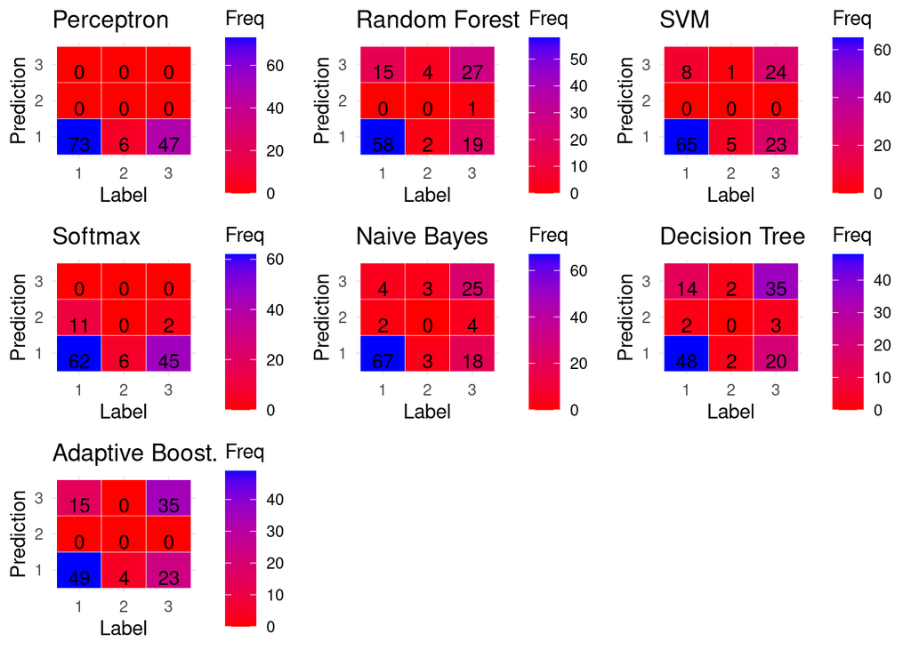

```r
confmat_plot <- function(confusion_df, ttl) {
  plot <- ggplot(confusion_df, aes(x = Reference, y = Prediction)) +
    geom_tile(aes(fill = Freq), color = "white") +
    geom_text(aes(label = Freq), vjust = 1) +
    scale_fill_gradient(low = "red", high = "blue") +
    theme_minimal() +
    labs(
      title = ttl,
      x = "Label",
      y = "Prediction"
    )
  plot
}

grid.arrange(
  confmat_plot(data.frame(get_best_model(percep_results)$table), "Perceptron"),
  confmat_plot(data.frame(get_best_model(randft_results)$table), "Random Forest"),
  confmat_plot(data.frame(get_best_model(svm_results)$table), "SVM"),
  confmat_plot(data.frame(get_best_model(soft_results)$table), "Softmax"),
  confmat_plot(data.frame(get_best_model(nbc_results)$table), "Naive Bayes"),
  confmat_plot(data.frame(get_best_model(dec_tree_results)$table), "Decision Tree"),
  confmat_plot(data.frame(get_best_model(adaboost_results)$table), "Adaptive Boost."),
  ncol = 3
)
```

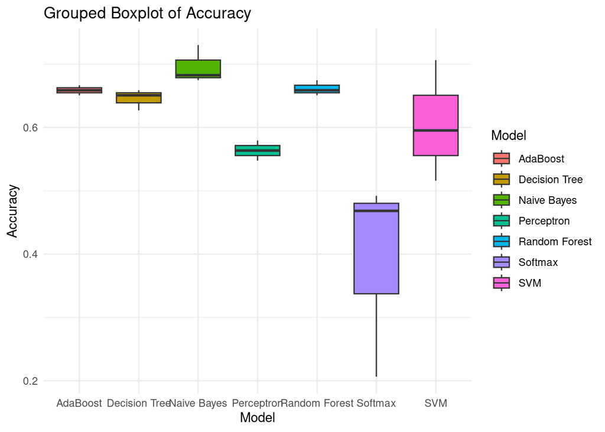

```r
models_results <- list(
  percep_results, randft_results, svm_results,
  soft_results, nbc_results, dec_tree_results, adaboost_results
)

accurracies <- vector("list", length = length(models_results))
idx_1 <- 1
for (model_results in models_results) {
  model_accurracy <- vector("list", length = length(model_results))
  idx_2 <- 1
  for (result in model_results) {
    model_accurracy[[idx_2]] <- result$overall[1]
    idx_2 <- idx_2 + 1
  }
  accurracies[[idx_1]] <- model_accurracy
  idx_1 <- idx_1 + 1
}

accuracy_model1 <- unlist(accurracies[[1]])
accuracy_model2 <- unlist(accurracies[[2]])
accuracy_model3 <- unlist(accurracies[[3]])
accuracy_model4 <- unlist(accurracies[[4]])
accuracy_model5 <- unlist(accurracies[[5]])
accuracy_model6 <- unlist(accurracies[[6]])
accuracy_model7 <- unlist(accurracies[[7]])

accuracy_df <- data.frame(
  Model = rep(c("Perceptron", "Random Forest", "SVM", "Softmax", "Naive Bayes", "Decision Tree", "AdaBoost"), each = length(accuracy_model1)),
  Accuracy = c(accuracy_model1, accuracy_model2, accuracy_model3, accuracy_model4, accuracy_model5, accuracy_model6, accuracy_model7)
)

ggplot(accuracy_df, aes(x = Model, y = Accuracy, fill = Model)) +
  geom_boxplot() +
  labs(title = "Grouped Boxplot of Accuracy", y = "Accuracy") +
  theme_minimal()
```

As observed, the accuracy of the models varies significantly between different models, as expected, beacuse each model has a different perspective and treatment of the data and are trained on a random subset of the cleaned dataset. It’s noteworthy that the Naive Bayes model has as the best-performing one, with a slight lead in accuracy. Additionally, the accuracy values remain relatively constant, unlike the Softmax model, which shows significant instability. The Adaptive Boosting and Random Forest models stands out with one of the highest accuracies and denote a remarkable consistency.

To conclude, it’s important to emphasize that determining the best model goes beyond the accuracy score alone. The choice depends on the model’s intended purpose, and it is essential to consider whether a more stable model is preferable or if one with higher variability and a better score is more suitable.